# Dual Burden of Stunting and Anaemia in Nigerian Under-5 Children

An analysis of data from the 2024 Nigeria Demographic and Health Survey

Ibari Joanna Nwosu

January 4, 2026

# 1 Introduction

Childhood stunting and anaemia remain among the most persistent and consequential forms of undernutrition globally, particularly in low- and middle-income countries. Stunting reflects chronic growth faltering that often originates in utero and accumulates during the first years of life, while anaemia in early childhood is commonly driven by micronutrient deficiencies, recurrent infection, and inadequate dietary intake (Black et al., 2013). Both conditions are associated with impaired cognitive development, increased morbidity, and long-term losses in human capital (Victora et al., 2021).

Nigeria bears a substantial share of this burden. Despite progress in some health indicators, child nutrition outcomes remain uneven, with pronounced inequalities by region, household wealth, maternal education, and place of residence (National Population Commission and ICF, 2024). While stunting and anaemia are often examined separately, growing attention has been paid to their coexistence within the same children, reflecting shared underlying determinants such as poverty, food insecurity, maternal undernutrition, and limited access to health services (Development Initiatives, 2018). Examining these outcomes together provides a fuller picture of cumulative nutritional disadvantage in early life.

Using data from the 2024 Nigeria Demographic and Health Survey (DHS), this report adopts a descriptive, equity-focused approach to examine childhood stunting and anaemia. It explores their distribution across geographic and socioeconomic groups and assesses the extent to which these two forms of undernutrition overlap among Nigerian children.

# 2 Context

Nigeria is divided into six geopolitical zones that differ substantially in socioeconomic conditions, maternal education, health service coverage, and food security. These differences shape childhood nutritional outcomes through multiple pathways, including maternal health and nutrition, infant feeding practices, and exposure to infectious disease.

Northern zones—particularly the North West and North East—tend to experience higher levels of poverty and lower female educational attainment than southern zones, while rural populations across the country face additional barriers to accessing preventive and curative health services (National Population Commission and ICF, 2024). Understanding the distribution of childhood stunting and anaemia therefore requires a geographically and socially disaggregated perspective.

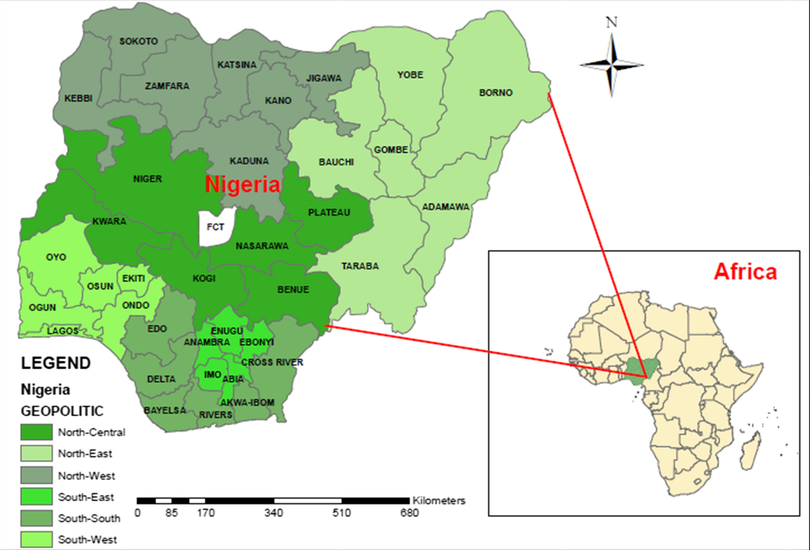

Map of Nigeria showing the states and geopolitical zones. Source: [Malaria Journal]

# 3 Objectives and methodology

This analysis aims to:

1. Describe the prevalence of childhood stunting (0–59 months) and anaemia (6–59 months) in Nigeria.
2. Examine geographic and socioeconomic inequalities in both outcomes.
3. Assess the coexistence of stunting and anaemia as a dual burden of chronic undernutrition and micronutrient deficiency.

This analysis uses data from the Nigeria DHS 2024 women’s individual recode, reshaped to a child-level dataset. Stunting is analysed among children aged 0–59 months, while anaemia is analysed among children aged 6–59 months, consistent with WHO and DHS guidance (World Health Organization, 2023; National Population Commission and ICF, 2024). Child records were derived from the women’s recode by pivoting child-specific variables to child-level records. Analyses are descriptive and unweighted.

Stunting is defined using WHO Child Growth Standards, with children classified as stunted if their height-for-age z-score is below −2 standard deviations, and severely stunted if below −3.

Anaemia is classified using updated WHO haemoglobin cut-offs (altitude-adjusted), with any anaemia defined as haemoglobin concentration below 10.5 g/dL among children aged 6–59 months. Custom anaemia levels are defined as: mild (9.5–10.4 g/dL), moderate (7.0–9.4 g/dL), and severe (<7.0 g/dL) (World Health Organization, 2023).

Outcomes are examined by geopolitical zone, maternal education, household wealth quintile, and urban–rural residence.

# 4 Results

## 4.1 Prevalence of childhood stunting and anaemia

| Table 1a: Stunting prevalence (0-59months) | Number | Percentage |
| --- | --- | --- |
| normal | 5,969 | 63.43 |
| stunted | 1,881 | 19.99 |
| severely stunted | 1,560 | 16.58 |
| Total | 9,410 | 100.00 |

| Table 1b: Anaemia prevalence (6-59 months) | Number | Percentage |
| --- | --- | --- |
| normal | 4,464 | 53.23 |
| mild anaemia | 2,081 | 24.81 |
| moderate anaemia | 1,720 | 20.51 |
| severe anaemia | 122 | 1.45 |
| Total | 8,387 | 100.00 |

**Interpretation:** Tables 1a and 1b summarise the overall distribution of childhood stunting and anaemia in Nigeria respectively. Stunting status is shown for children aged 0–59 months, while anaemia status is shown for children aged 6–59 months, consistent with DHS and WHO guidance. A substantial proportion of children are affected by each condition. While most children fall within the “normal” category for both outcomes, sizeable shares are classified as stunted or anaemic, and a smaller subset experience severe forms. This figure establishes the scale of the problem and motivates subsequent analyses exploring inequalities across socioeconomic and geographic groups.

## 4.2 Childhood stunting by socioeconomic and geographic characteristics

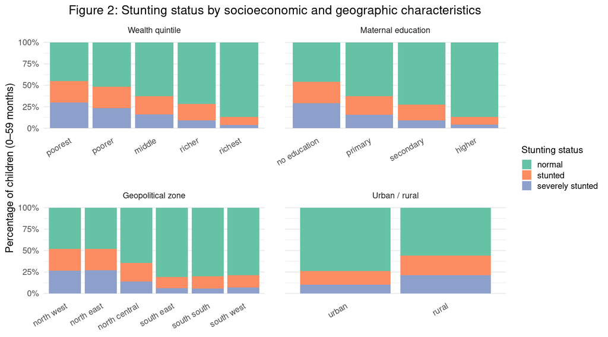

**Interpretation:** Figure 2 shows the distribution of stunting status by household wealth quintile, maternal education, geopolitical zone, and place of residence. Clear socioeconomic gradients are evident: the proportion of children who are stunted or severely stunted declines with increasing household wealth and maternal education. Rural children show a higher burden than urban children. Marked regional disparities are also observed, with northern zones—especially the North West and North East—showing higher levels of stunting than southern zones.

## 4.3 Childhood anaemia by socioeconomic and geographic characteristics

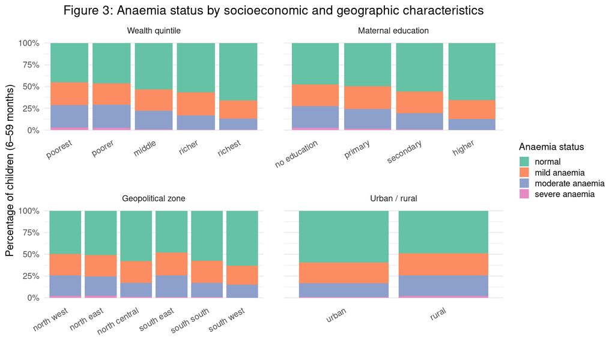

## 4.4 Distributions of height-for-age z-scores and haemoglobin levels by household wealth quintile

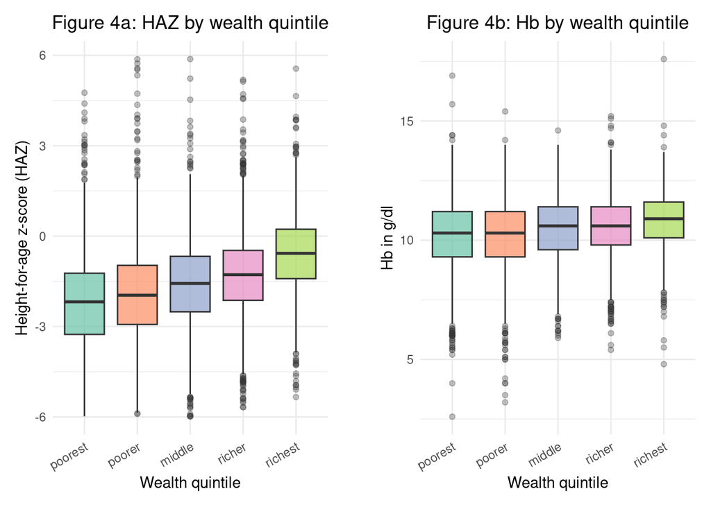

**Interpretation:** Figures 4a and 4b complement the categorical results shown earlier by plotting the distribution of continuous height-for-age z-scores and haemoglobin levels across household wealth quintiles. For both indicators, median values are higher among wealthier households, and the distributions are shifted upward relative to poorer quintiles. These patterns suggest that observed socioeconomic differences in stunting and anaemia prevalence are reflected across the full distributions of growth and haemoglobin status.

## 4.5 Dual burden of stunting and anaemia by geopolitical zone

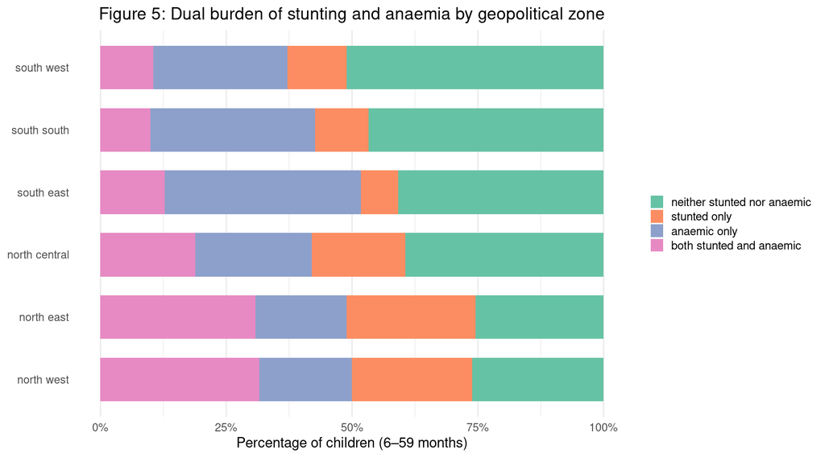

**Interpretation:** Figure 5 presents the combined burden of stunting and anaemia among children aged 6–59 months by geopolitical zone. Children are classified into four mutually exclusive categories: neither condition, stunted only, anaemic only, and both stunted and anaemic. Across all zones, a substantial share of children experience at least one form of undernutrition. Importantly, the coexistence of stunting and anaemia is present in every zone, though it is more pronounced in the northern regions. Southern zones tend to have a larger share of children free from both conditions, but still exhibit notable levels of combined burden.

## 4.6 Association between HAZ and haemoglobin with cutoffs

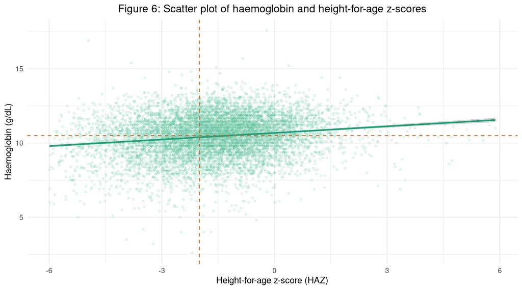

**Interpretation:** Figure 6 shows the relationship between continuous height-for-age z-scores and haemoglobin concentration among children aged 6–59 months. The fitted regression line suggests a weak positive association, indicating that children with better linear growth tend, on average, to have higher haemoglobin levels. However, substantial variability is evident. The dashed reference lines mark the WHO cut-offs for stunting (HAZ < −2) and anaemia (Hb < 10.5 g/dL), reinforcing the finding that a large proportion of children fall below one or both thresholds.

# 5 Discussion

These descriptive findings point to a persistent burden of chronic undernutrition and micronutrient deficiency among Nigerian children. The concentration of both stunting and anaemia in the northeast and northwest is particularly striking: in these zones, over one quarter of under-five children experience both conditions, while roughly three quarters of under-five children are affected by at least one of them. Prevalence of both conditions is consistently higher among children from poorer households, those with less-educated mothers, and those living in rural areas, highlighting the central effect of structural disadvantage in shaping early-life nutritional outcomes (Victora et al., 2021; National Population Commission and ICF, 2024).

Importantly, the overlap between stunting and anaemia is substantial, indicating that many children face compounded nutritional risks rather than isolated deficiencies. This dual burden likely reflects cumulative and sustained nutritional deprivation across the early life course, and is associated with heightened risks for impaired growth, cognitive development, and long-term health. The findings align with a wider body of evidence identifying early childhood as a critical window for preventing long-term nutritional harm (Development Initiatives, 2018; Stevens et al., 2022). Overall, this analysis underscores the need for integrated child nutrition strategies that address dietary adequacy, coupled with attention to the broader social and economic conditions that constrain child health in Nigeria.

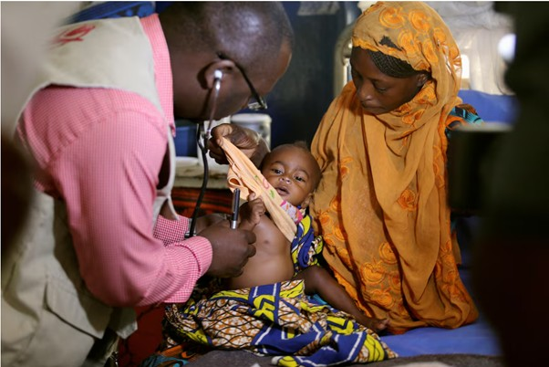

A doctor examines a malnourished baby at the Save the Children stabilisation ward in Maiduguri, Nigeria. Source: [Save the Children]

# 6 Conclusion

Childhood stunting and anaemia remain major public health challenges in Nigeria, reflecting persistent socioeconomic and regional inequalities. Addressing this dual burden requires coordinated interventions that improve maternal nutrition, enhance dietary quality in early childhood, and reduce structural barriers to health and nutrition services. Descriptive analyses using DHS data are valuable for monitoring inequalities and informing policies aimed at improving child nutrition and developmental outcomes.

# 7 Acknowledgements

I would like to express my gratitude to [**The Graph Courses**](https://thegraphcourses.org/) for the scholarship that enabled me to join the 2025 Quarter 4 R Basics and Beyond Bootcamp.

# 8 References

Black, R.E. *et al.* (2013) ‘Maternal and child undernutrition and overweight in low-income and middle-income countries’, *The Lancet*, 382(9890), pp. 427–451.

Development Initiatives (2018) *2018 Global Nutrition Report: Shining a light to spur action on nutrition*. Bristol: Development Initiatives.

Kassebaum, N.J. *et al.* (2016) ‘A systematic analysis of global anaemia burden from 1990 to 2010’, *Blood*, 123(5), pp. 615–624.

National Population Commission (NPC) [Nigeria] and ICF (2024) *Nigeria Demographic and Health Survey 2023/24*. Abuja, Nigeria, and Rockville, Maryland, USA.

Stevens, G.A. *et al.* (2022) ‘Global prevalence and trends in anaemia in women and children’, *The Lancet Global Health*, 10(5), pp. e713–e723.

Victora, C.G. *et al.* (2010) ‘Worldwide timing of growth faltering: Revisiting implications for interventions’, *Pediatrics*, 125(3), pp. e473–e480.

Victora, C.G. *et al.* (2021) ‘Revisiting maternal and child undernutrition in low-income and middle-income countries’, *The Lancet*, 397(10282), pp. 1382–1399.

World Health Organization (2023) *WHO guideline on haemoglobin cutoffs to define anaemia*. Geneva: WHO.